# Modeling

2022-11-07

Import the cleaned and orgnized data:

```r
dataset = read.csv(file = 'mbti_orgnized.csv')
dataset$EorI <- as.factor(dataset$EorI)
dataset$NorS <- as.factor(dataset$NorS)
dataset$TorF <- as.factor(dataset$TorF)
dataset$JorP <- as.factor(dataset$JorP)
dataset$type <- as.factor(dataset$type)
head(dataset)
```

|  | X | type | posts | EorI | NorS | TorF | JorP | avg_comment_length | comment_length_var | Sentiment | Ellipses | Exclamation | Question | Links | Picture | Emojies | Upper |
| --- | --- | --- | --- | --- | --- | --- | --- | --- | --- | --- | --- | --- | --- | --- | --- | --- | --- |
| 1 | 0 | INFJ | 'http://www.youtube.com/watch?v=qsXHcwe3krw\|\|\|http://41.media.tumblr.com/tumblr_lfouy03PMA1qa1rooo1_500.jpg\|\|\|enfp and intj moments https://www.youtube.com/watch?v=iz7lE1g4XM4 sportscenter not t… | 0 | 0 | 0 | 0 | 11.12 | 135.2900 | 0.9971993 | 8 | 3 | 18 | 24 | 6 | 4 | 13 |
| 2 | 1 | ENTP | 'I'm finding the lack of me in these posts very alarming.\|\|\|Sex can be boring if it's in the same position often. For example me and my girlfriend are currently in an environment where we have to c… | 1 | 0 | 1 | 1 | 23.40 | 187.4756 | 0.9993998 | 18 | 0 | 5 | 9 | 8 | 14 | 82 |
| 3 | 2 | INTP | 'Good one _____ https://www.youtube.com/watch?v=fHiGbolFFGw\|\|\|Of course, to which I say I know; that's my blessing and my curse.\|\|\|Does being absolutely positive that you and your best friend co… | 0 | 0 | 1 | 1 | 16.72 | 180.6900 | 0.9992498 | 13 | 4 | 12 | 4 | 0 | 10 | 26 |
| 4 | 3 | INTJ | 'Dear INTP, I enjoyed our conversation the other day. Esoteric gabbing about the nature of the universe and the idea that every rule and social code being arbitrary constructs created...\|\|\|Dear ENT… | 0 | 0 | 1 | 0 | 21.28 | 181.8324 | 0.9992498 | 23 | 3 | 11 | 2 | 0 | 0 | 57 |
| 5 | 4 | ENTJ | 'You're fired.\|\|\|That's another silly misconception. That approaching is logically is going to be the key to unlocking whatever it is you think you are entitled to. Nobody wants to be approached wi… | 1 | 0 | 1 | 0 | 19.34 | 196.4576 | 0.9937484 | 20 | 1 | 10 | 6 | 2 | 1 | 35 |
| 6 | 5 | INTJ | '18/37 @.@\|\|\|Science is not perfect. No scientist claims that it is, or that scientific information will not be revised as we discover new things. Rational thinking has been very useful to our soci… | 0 | 0 | 1 | 0 | 29.82 | 97.7200 | 0.9980495 | 34 | 0 | 10 | 1 | 0 | 0 | 74 |

EDA:

```r
dim(dataset)
```

```
## [1] 8675   17
```

```r
#From the dataset, we can see that there are in total 8675 observations and 17 dimensions. Within the 17 dimensions, we will mainly use the latter 10 variables to do the classification modeling.
summary(dataset)
```

```
##        X             type         posts           EorI     NorS     TorF
##  Min.   :   0   INFP   :1832   Length:8675        0:6676   0:7478   0:4694
##  1st Qu.:2168   INFJ   :1470   Class :character   1:1999   1:1197   1:3981
##  Median :4337   INTP   :1304   Mode  :character
##  Mean   :4337   INTJ   :1091
##  3rd Qu.:6506   ENTP   : 685
##  Max.   :8674   ENFP   : 675
##                 (Other):1618
##  JorP     avg_comment_length comment_length_var   Sentiment
##  0:3434   Min.   : 0.08      Min.   :  0.0      Min.   :0.0000
##  1:5241   1st Qu.:20.93      1st Qu.:105.5      1st Qu.:0.9984
##           Median :25.56      Median :140.3      Median :0.9994
##           Mean   :24.52      Mean   :137.2      Mean   :0.9748
##           3rd Qu.:29.14      3rd Qu.:170.5      3rd Qu.:0.9997
##           Max.   :37.62      Max.   :313.3      Max.   :1.0000
##
##     Ellipses      Exclamation         Question          Links
##  Min.   : 0.00   Min.   :  0.000   Min.   :  0.00   Min.   : 0.000
##  1st Qu.:19.00   1st Qu.:  2.000   1st Qu.:  6.00   1st Qu.: 0.000
##  Median :27.00   Median :  5.000   Median : 10.00   Median : 1.000
##  Mean   :26.09   Mean   :  8.454   Mean   : 10.73   Mean   : 3.247
##  3rd Qu.:34.00   3rd Qu.: 11.000   3rd Qu.: 14.00   3rd Qu.: 4.000
##  Max.   :49.00   Max.   :219.000   Max.   :121.00   Max.   :90.000
##
##     Picture           Emojies           Upper
##  Min.   : 0.0000   Min.   : 0.000   Min.   :  0.00
##  1st Qu.: 0.0000   1st Qu.: 1.000   1st Qu.: 45.00
##  Median : 0.0000   Median : 3.000   Median : 64.00
##  Mean   : 0.8076   Mean   : 5.406   Mean   : 64.35
##  3rd Qu.: 1.0000   3rd Qu.: 7.000   3rd Qu.: 83.00
##  Max.   :46.0000   Max.   :91.000   Max.   :204.00
##
```

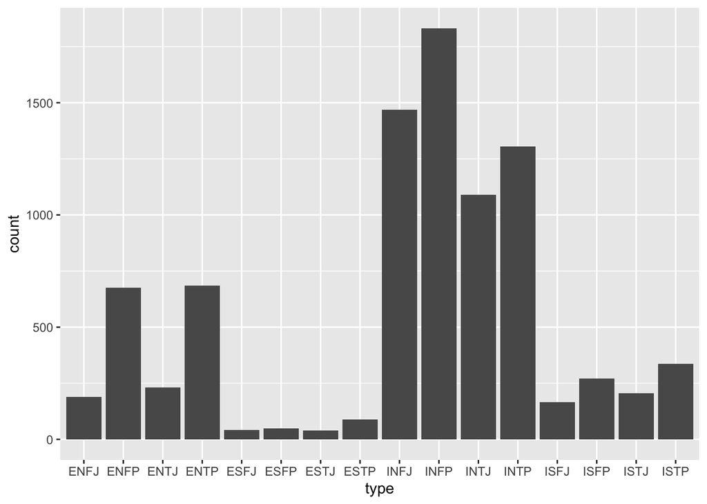

```r
ggplot(data = dataset) +
  geom_bar(mapping = aes(x = type))
```

#From the plot we can see that INFJ, INFP, INTP, and INTJ are the major components of the sample. Also, it is noteworthy that we have very little data about ESFJ, ESFP, ESTJ, ESTP. This is an interesting phenomenon since it implies that people with IN personality might be more active online while people with ES personality might be the least active online(because the data is collected from an online forum.)

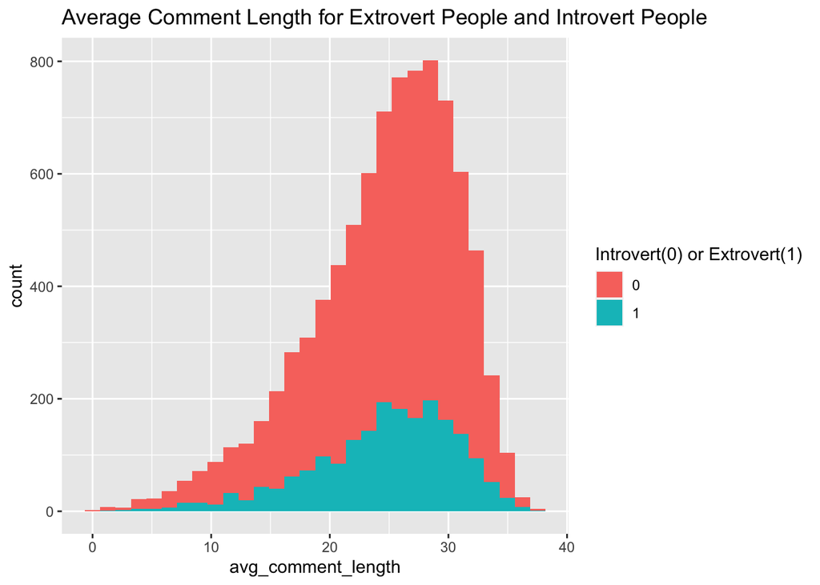

```r
#EDA Question 1: Does extrovert people overall speak more than introvert people?
ggplot(data=dataset, aes(x=avg_comment_length,fill = EorI)) +
  geom_histogram() + ggtitle("Average Comment Length for Extrovert People and Introvert People")+
  labs(fill = "Introvert(0) or Extrovert(1)")
```

```r
dataset %>% group_by(EorI) %>%
  summarize(
    count = mean(avg_comment_length)
  )
```

| EorI | count |
| --- | --- |
| 0 | 24.5057 |
| 1 | 24.5887 |

#From the summary table, we conclude that the average comment length for extrovert people is 24.5887, which is pretty close to introvert people’s 24.5057. In other words, there is no significant difference in the average comment length between extrovert people and introvert people.

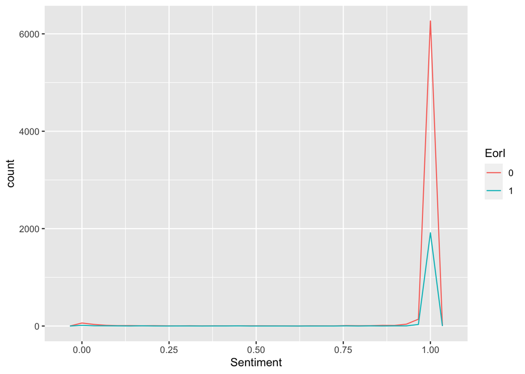

```r
#Question2: Will extrovert people have more positive feelings(measured by sentiment score)?

ggplot(data=dataset, aes(x=Sentiment,color = EorI)) +
  geom_freqpoly()
```

```r
dataset %>% group_by(EorI) %>%
  summarize(
    count = mean(Sentiment)
  )
```

| EorI | count |
| --- | --- |
| 0 | 0.9731000 |
| 1 | 0.9803589 |

```r
#Extroversion or Introversion
a1<-ggplot(dataset, aes(avg_comment_length, colour = EorI)) +
  geom_freqpoly(binwidth = 1)

b1<-ggplot(dataset, aes(comment_length_var, colour = EorI)) +
  geom_freqpoly(binwidth = 1)

c1<-ggplot(dataset, aes(Sentiment, colour = EorI)) +
  geom_freqpoly(binwidth = 1)

d1<-ggplot(dataset, aes(Ellipses, colour = EorI)) +
  geom_freqpoly(binwidth = 1)

e1<-ggplot(dataset, aes(Exclamation, colour = EorI)) +
  geom_freqpoly(binwidth = 1)

f1<-ggplot(dataset, aes(Question, colour = EorI)) +
  geom_freqpoly(binwidth = 1)

g1<-ggplot(dataset, aes(Links, colour = EorI)) +
  geom_freqpoly(binwidth = 1)

h1<-ggplot(dataset, aes(Picture, colour = EorI)) +
  geom_freqpoly(binwidth = 1)

i1<-ggplot(dataset, aes(Emojies, colour = EorI)) +
  geom_freqpoly(binwidth = 1)

j1<-ggplot(dataset, aes(Upper, colour = EorI)) +
  geom_freqpoly(binwidth = 1)
```

```r
#Sensing or Intuition
a2<-ggplot(dataset, aes(avg_comment_length, colour = NorS)) +
  geom_freqpoly(binwidth = 1)

b2<-ggplot(dataset, aes(comment_length_var, colour = NorS)) +
  geom_freqpoly(binwidth = 1)

c2<-ggplot(dataset, aes(Sentiment, colour = NorS)) +
  geom_freqpoly(binwidth = 1)

d2<-ggplot(dataset, aes(Ellipses, colour = NorS)) +
  geom_freqpoly(binwidth = 1)

e2<-ggplot(dataset, aes(Exclamation, colour = NorS)) +
  geom_freqpoly(binwidth = 1)

f2<-ggplot(dataset, aes(Question, colour = NorS)) +
  geom_freqpoly(binwidth = 1)

g2<-ggplot(dataset, aes(Links, colour = NorS)) +
  geom_freqpoly(binwidth = 1)

h2<-ggplot(dataset, aes(Picture, colour = NorS)) +
  geom_freqpoly(binwidth = 1)

i2<-ggplot(dataset, aes(Emojies, colour = NorS)) +
  geom_freqpoly(binwidth = 1)

j2<-ggplot(dataset, aes(Upper, colour = NorS)) +
  geom_freqpoly(binwidth = 1)
```

```r
#Thinking or Feeling
a3<-ggplot(dataset, aes(avg_comment_length, colour = TorF)) +
  geom_freqpoly(binwidth = 1)

b3<-ggplot(dataset, aes(comment_length_var, colour = TorF)) +
  geom_freqpoly(binwidth = 1)

c3<-ggplot(dataset, aes(Sentiment, colour = TorF)) +
  geom_freqpoly(binwidth = 1)

d3<-ggplot(dataset, aes(Ellipses, colour = TorF)) +
  geom_freqpoly(binwidth = 1)
e3<-ggplot(dataset, aes(Exclamation, colour = TorF)) +
  geom_freqpoly(binwidth = 1)

f3<-ggplot(dataset, aes(Question, colour = TorF)) +
  geom_freqpoly(binwidth = 1)

g3<-ggplot(dataset, aes(Links, colour = TorF)) +
  geom_freqpoly(binwidth = 1)

h3<-ggplot(dataset, aes(Picture, colour = TorF)) +
  geom_freqpoly(binwidth = 1)

i3<-ggplot(dataset, aes(Emojies, colour = TorF)) +
  geom_freqpoly(binwidth = 1)

j3<-ggplot(dataset, aes(Upper, colour = TorF)) +
  geom_freqpoly(binwidth = 1) + labs(title="Upper Distribution by Outcome")
```

```r
#Judging or Perceiving
a4<-ggplot(dataset, aes(avg_comment_length, colour = JorP)) +
  geom_freqpoly(binwidth = 1)

b4<-ggplot(dataset, aes(comment_length_var, colour = JorP)) +
  geom_freqpoly(binwidth = 1)

c4<-ggplot(dataset, aes(Sentiment, colour = JorP)) +
  geom_freqpoly(binwidth = 1)

d4<-ggplot(dataset, aes(Ellipses, colour = JorP)) +
  geom_freqpoly(binwidth = 1)

e4<-ggplot(dataset, aes(Exclamation, colour = JorP)) +
  geom_freqpoly(binwidth = 1)

f4<-ggplot(dataset, aes(Question, colour = JorP)) +
  geom_freqpoly(binwidth = 1)

g4<-ggplot(dataset, aes(Links, colour = JorP)) +
  geom_freqpoly(binwidth = 1)

h4<-ggplot(dataset, aes(Picture, colour = JorP)) +
  geom_freqpoly(binwidth = 1)

i4<-ggplot(dataset, aes(Emojies, colour = JorP)) +
  geom_freqpoly(binwidth = 1)

j4<-ggplot(dataset, aes(Upper, colour = JorP)) +
  geom_freqpoly(binwidth = 1) + labs(title="Upper Distribution by Outcome")
```

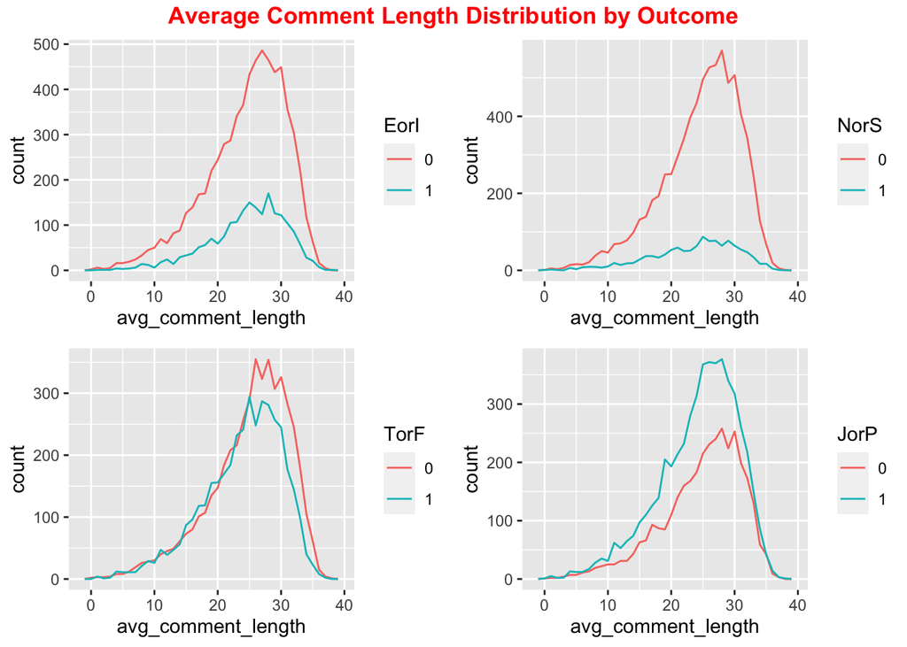

```r
avg_comment_length <- ggarrange(a1,a2,a3,a4,
                    ncol = 2, nrow = 2)
annotate_figure(avg_comment_length, top = text_grob("Average Comment Length Distribution by Outcome", color = "red", face = "bold", size = 13))
```

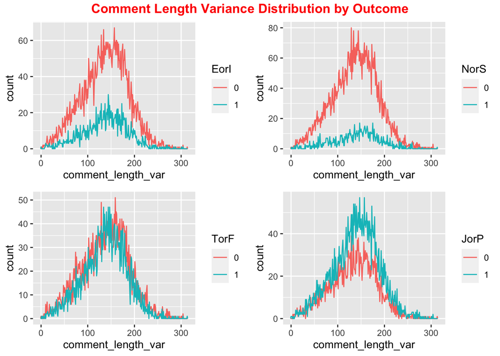

```r
comment_length_var <- ggarrange(b1,b2,b3,b4,
                    ncol = 2, nrow = 2)
annotate_figure(comment_length_var, top = text_grob("Comment Length Variance Distribution by Outcome", color = "red", face = "bold", size = 13))
```

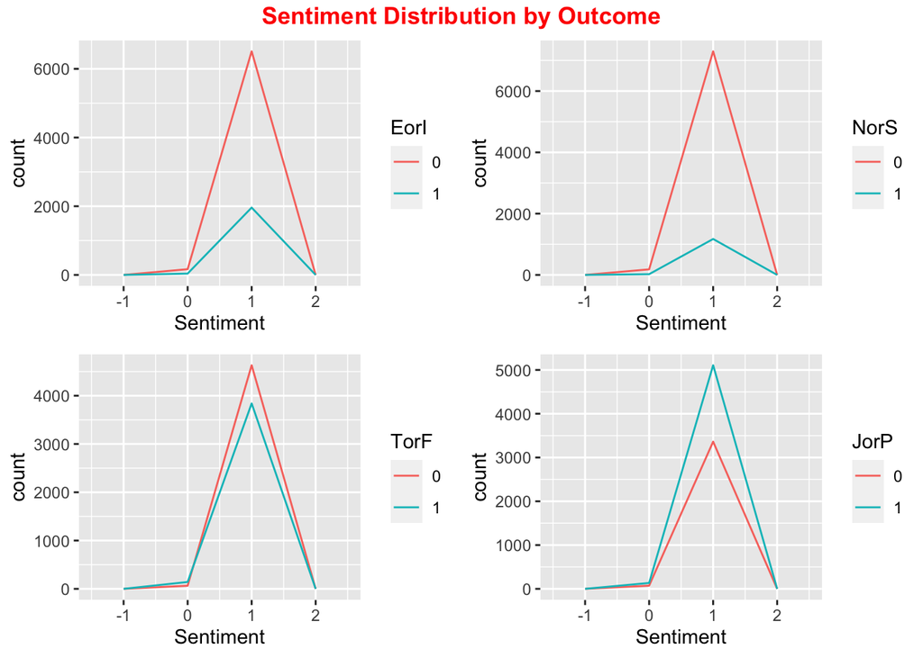

```r
Sentiment <- ggarrange(c1,c2,c3,c4,
                    ncol = 2, nrow = 2)
annotate_figure(Sentiment, top = text_grob("Sentiment Distribution by Outcome", color = "red", face = "bold", size = 13))
```

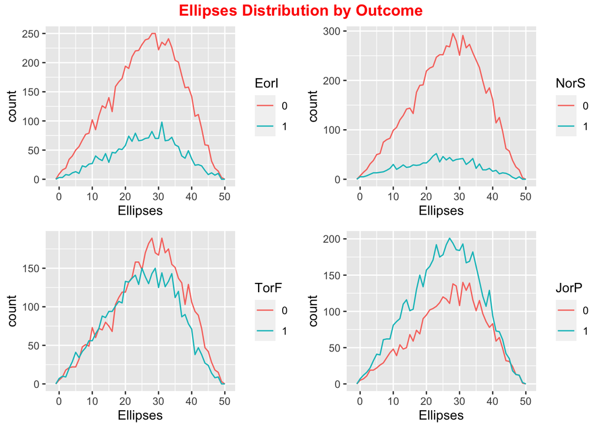

```r
Ellipses <- ggarrange(d1,d2,d3,d4,
                    ncol = 2, nrow = 2)
annotate_figure(Ellipses, top = text_grob("Ellipses Distribution by Outcome", color = "red", face = "bold", size = 13))
```

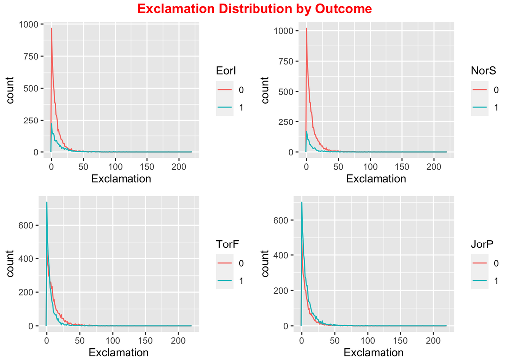

```r
Exclamation <- ggarrange(e1,e2,e3,e4,
                    ncol = 2, nrow = 2)
annotate_figure(Exclamation, top = text_grob("Exclamation Distribution by Outcome", color = "red", face = "bold", size = 13))
```

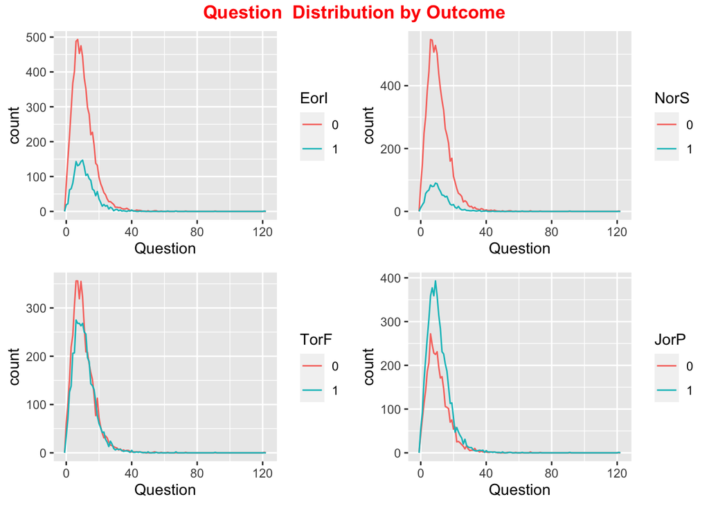

```r
Question  <- ggarrange(f1,f2,f3,f4,
                    ncol = 2, nrow = 2)
annotate_figure(Question , top = text_grob("Question  Distribution by Outcome", color = "red", face = "bold", size = 13))
```

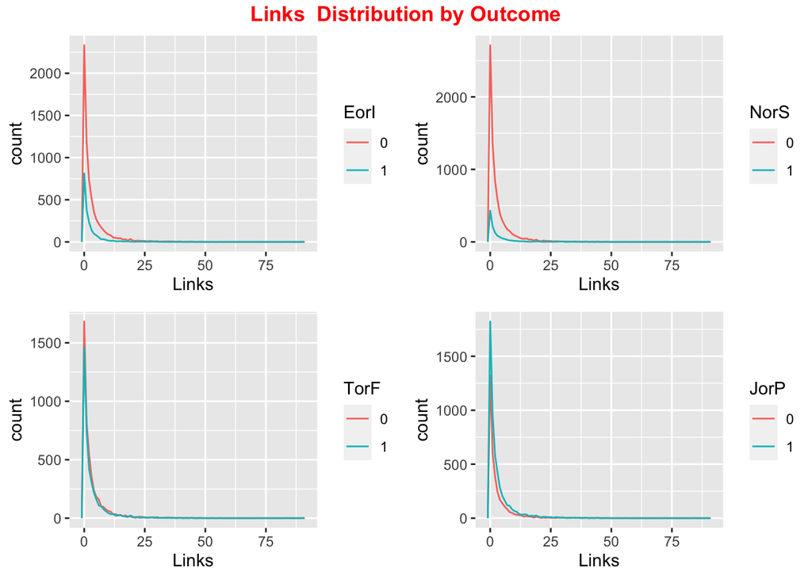

```r
Links  <- ggarrange(g1,g2,g3,g4,
                    ncol = 2, nrow = 2)
annotate_figure(Links , top = text_grob("Links  Distribution by Outcome", color = "red", face = "bold", size = 13))
```

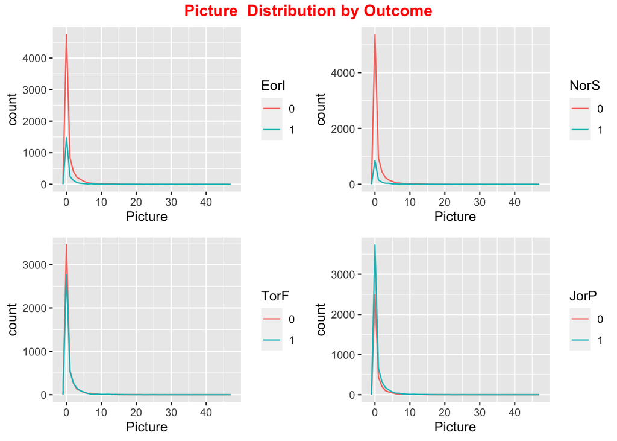

```r
Picture <- ggarrange(h1,h2,h3,h4,
                    ncol = 2, nrow = 2)
annotate_figure(Picture , top = text_grob("Picture  Distribution by Outcome", color = "red", face = "bold", size = 13))
```

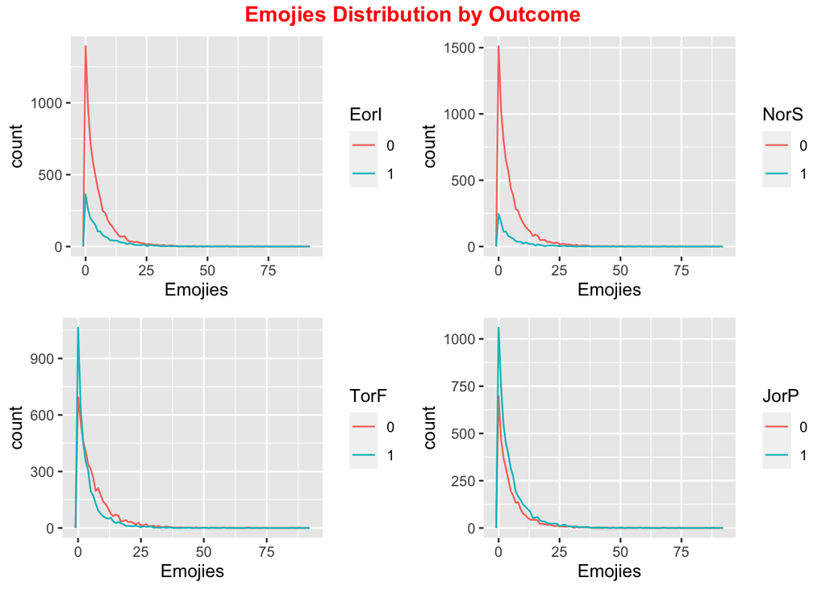

```r
Emojies <- ggarrange(i1,i2,i3,i4,
                    ncol = 2, nrow = 2)
annotate_figure(Emojies, top = text_grob("Emojies Distribution by Outcome", color = "red", face = "bold", size = 13))
```

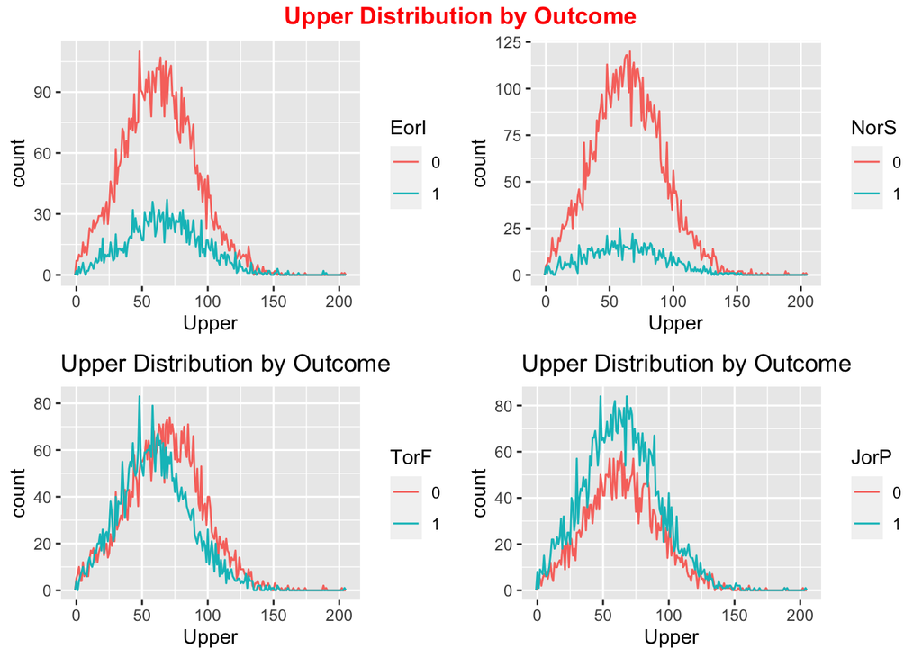

```r
Upper <- ggarrange(j1,j2,j3,j4,
                    ncol = 2, nrow = 2)
annotate_figure(Upper, top = text_grob("Upper Distribution by Outcome", color = "red", face = "bold", size = 13))
```

First thing to do, we need to split the whole data into training and testing:

```r
set.seed(123)
a = seq(1,nrow(dataset),by=1)
inTrain <- sample(a,nrow(dataset)*0.8, replace=FALSE)
training <- dataset[inTrain,]
testing <- dataset[-inTrain,]
```

First of all, we will try multi-classification of these 16 types of personalities. Using naive bayes:

```r
classifier_NB <- naiveBayes(type ~ avg_comment_length + comment_length_var + Sentiment + Ellipses + Exclamation + Question + Links + Picture + Emojies + Upper, data = training, usekernel = T)
y_pred_NB <- predict(classifier_NB, newdata = testing)
cm_NB <- table(testing$type, y_pred_NB)
cm_NB
```

```
##       y_pred_NB
##        ENFJ ENFP ENTJ ENTP ESFJ ESFP ESTJ ESTP INFJ INFP INTJ INTP ISFJ ISFP
##   ENFJ    0    2    0    1   13    2    0    2    9    3    1    2    0    1
##   ENFP    0   26    4    1   46    7    0    0   23    8    6    6    0    4
##   ENTJ    0    5    1    1   12    0    1    1   14    2    1    6    0    0
##   ENTP    0    5    6    0   35    2    0    0   36   10   16   23    0    2
##   ESFJ    0    3    0    0    2    1    0    0    0    0    1    0    0    0
##   ESFP    0    0    0    0    1    0    0    0    2    1    0    0    0    0
##   ESTJ    0    1    0    0    0    0    0    1    5    1    0    1    0    0
##   ESTP    0    0    2    1    5    1    0    0    2    1    3    4    0    0
##   INFJ    0   22    3    1   98    6    2    0   82   28   20   26    0    2
##   INFP    0   34    8    1  102    6    2    3   97   33   26   39    0    8
##   INTJ    0    9    6    1   54    2    1    3   45   14   22   43    0    3
##   INTP    0    7    5    2   61    3    2    4   78   13   35   61    0    0
##   ISFJ    0    6    1    0   16    0    0    0    6    1    5    1    0    1
##   ISFP    0    7    1    0   11    1    0    0    9    3    8    4    0    1
##   ISTJ    0    4    0    1   10    1    1    0   13    3    2    3    0    0
##   ISTP    0    0    2    0   14    0    1    1   20    3    9   14    0    2
##       y_pred_NB
##        ISTJ ISTP
##   ENFJ    0    1
##   ENFP    0    2
##   ENTJ    0    1
##   ENTP    0    1
##   ESFJ    0    0
##   ESFP    0    0
##   ESTJ    0    0
##   ESTP    0    0
##   INFJ    0    5
##   INFP    0    9
##   INTJ    0    4
##   INTP    0    8
##   ISFJ    0    2
##   ISFP    0    2
##   ISTJ    0    3
##   ISTP    0    3
```

```r
confusionMatrix(cm_NB)
```

```
## Confusion Matrix and Statistics
##
##       y_pred_NB
##        ENFJ ENFP ENTJ ENTP ESFJ ESFP ESTJ ESTP INFJ INFP INTJ INTP ISFJ ISFP
##   ENFJ    0    2    0    1   13    2    0    2    9    3    1    2    0    1
##   ENFP    0   26    4    1   46    7    0    0   23    8    6    6    0    4
##   ENTJ    0    5    1    1   12    0    1    1   14    2    1    6    0    0
##   ENTP    0    5    6    0   35    2    0    0   36   10   16   23    0    2
##   ESFJ    0    3    0    0    2    1    0    0    0    0    1    0    0    0
##   ESFP    0    0    0    0    1    0    0    0    2    1    0    0    0    0
##   ESTJ    0    1    0    0    0    0    0    1    5    1    0    1    0    0
##   ESTP    0    0    2    1    5    1    0    0    2    1    3    4    0    0
##   INFJ    0   22    3    1   98    6    2    0   82   28   20   26    0    2
##   INFP    0   34    8    1  102    6    2    3   97   33   26   39    0    8
##   INTJ    0    9    6    1   54    2    1    3   45   14   22   43    0    3
##   INTP    0    7    5    2   61    3    2    4   78   13   35   61    0    0
##   ISFJ    0    6    1    0   16    0    0    0    6    1    5    1    0    1
##   ISFP    0    7    1    0   11    1    0    0    9    3    8    4    0    1
##   ISTJ    0    4    0    1   10    1    1    0   13    3    2    3    0    0
##   ISTP    0    0    2    0   14    0    1    1   20    3    9   14    0    2
##       y_pred_NB
##        ISTJ ISTP
##   ENFJ    0    1
##   ENFP    0    2
##   ENTJ    0    1
##   ENTP    0    1
##   ESFJ    0    0
##   ESFP    0    0
##   ESTJ    0    0
##   ESTP    0    0
##   INFJ    0    5
##   INFP    0    9
##   INTJ    0    4
##   INTP    0    8
##   ISFJ    0    2
##   ISFP    0    2
##   ISTJ    0    3
##   ISTP    0    3
##
## Overall Statistics
```

[output cut: 33 more lines]

```
## Pos Pred Value           0.27797     0.08967     0.10628     0.21864
## Neg Pred Value           0.75069     0.93343     0.91296     0.88187
## Prevalence               0.25418     0.07147     0.08934     0.13429
## Detection Rate           0.04726     0.01902     0.01268     0.03516
## Detection Prevalence     0.17003     0.21210     0.11931     0.16081
## Balanced Accuracy        0.51067     0.52909     0.51242     0.55833
##                      Class: ISFJ Class: ISFP Class: ISTJ Class: ISTP
## Sensitivity                   NA   0.0416667          NA    0.073171
## Specificity              0.97752   0.9731151     0.97637    0.961039
## Pos Pred Value                NA   0.0212766          NA    0.043478
## Neg Pred Value                NA   0.9863744          NA    0.977191
## Prevalence               0.00000   0.0138329     0.00000    0.023631
## Detection Rate           0.00000   0.0005764     0.00000    0.001729
## Detection Prevalence     0.02248   0.0270893     0.02363    0.039769
## Balanced Accuracy             NA   0.5073909          NA    0.517105
```

Using random forest:

```r
classifier_RF <- randomForest(type ~ avg_comment_length + comment_length_var + Sentiment + Ellipses + Exclamation + Question + Links + Picture + Emojies + Upper, data = training,importance=TRUE)
y_pred_RF = predict(classifier_RF, newdata = testing)
cm_RF <- table(testing$type, y_pred_RF)
cm_RF
```

```
##       y_pred_RF
##        ENFJ ENFP ENTJ ENTP ESFJ ESFP ESTJ ESTP INFJ INFP INTJ INTP ISFJ ISFP
##   ENFJ    0    2    0    0    0    0    0    0    6   22    2    5    0    0
##   ENFP    0   20    0    2    0    0    0    0   26   68    7    9    0    0
##   ENTJ    1    3    0    0    0    0    0    0    8   15    7   11    0    0
##   ENTP    0    2    0    3    0    0    0    0   25   47   22   36    0    0
##   ESFJ    0    1    0    0    0    0    0    0    2    2    2    0    0    0
##   ESFP    0    0    0    1    0    0    0    0    1    1    1    0    0    0
##   ESTJ    0    0    0    0    0    0    0    0    1    3    3    2    0    0
##   ESTP    0    1    0    3    0    0    0    0    2    7    2    4    0    0
##   INFJ    0   16    0    2    0    0    0    0   67  131   31   47    0    0
##   INFP    0   16    0    4    0    0    0    0   97  162   17   70    0    1
##   INTJ    0    2    0    4    0    0    0    0   31   74   25   69    0    0
##   INTP    0    5    1    6    0    0    0    0   48   80   42   96    0    0
##   ISFJ    0    2    0    0    0    0    0    0   11   19    3    4    0    0
##   ISFP    0    3    0    0    0    0    0    0    9   21    4   10    0    0
##   ISTJ    0    1    0    0    0    0    0    0    7   20    2   11    0    0
##   ISTP    0    0    0    1    0    0    0    0   11   21   11   25    0    0
##       y_pred_RF
##        ISTJ ISTP
##   ENFJ    0    0
##   ENFP    1    0
##   ENTJ    0    0
##   ENTP    0    1
##   ESFJ    0    0
##   ESFP    0    0
##   ESTJ    0    0
##   ESTP    0    0
##   INFJ    0    1
##   INFP    0    1
##   INTJ    1    1
##   INTP    0    1
##   ISFJ    0    0
##   ISFP    0    0
##   ISTJ    0    0
##   ISTP    0    0
```

```r
confusionMatrix(cm_RF)
```

```
## Confusion Matrix and Statistics
##
##       y_pred_RF
##        ENFJ ENFP ENTJ ENTP ESFJ ESFP ESTJ ESTP INFJ INFP INTJ INTP ISFJ ISFP
##   ENFJ    0    2    0    0    0    0    0    0    6   22    2    5    0    0
##   ENFP    0   20    0    2    0    0    0    0   26   68    7    9    0    0
##   ENTJ    1    3    0    0    0    0    0    0    8   15    7   11    0    0
##   ENTP    0    2    0    3    0    0    0    0   25   47   22   36    0    0
##   ESFJ    0    1    0    0    0    0    0    0    2    2    2    0    0    0
##   ESFP    0    0    0    1    0    0    0    0    1    1    1    0    0    0
##   ESTJ    0    0    0    0    0    0    0    0    1    3    3    2    0    0
##   ESTP    0    1    0    3    0    0    0    0    2    7    2    4    0    0
##   INFJ    0   16    0    2    0    0    0    0   67  131   31   47    0    0
##   INFP    0   16    0    4    0    0    0    0   97  162   17   70    0    1
##   INTJ    0    2    0    4    0    0    0    0   31   74   25   69    0    0
##   INTP    0    5    1    6    0    0    0    0   48   80   42   96    0    0
##   ISFJ    0    2    0    0    0    0    0    0   11   19    3    4    0    0
##   ISFP    0    3    0    0    0    0    0    0    9   21    4   10    0    0
##   ISTJ    0    1    0    0    0    0    0    0    7   20    2   11    0    0
##   ISTP    0    0    0    1    0    0    0    0   11   21   11   25    0    0
##       y_pred_RF
##        ISTJ ISTP
##   ENFJ    0    0
##   ENFP    1    0
##   ENTJ    0    0
##   ENTP    0    1
##   ESFJ    0    0
##   ESFP    0    0
##   ESTJ    0    0
##   ESTP    0    0
##   INFJ    0    1
##   INFP    0    1
##   INTJ    1    1
##   INTP    0    1
##   ISFJ    0    0
##   ISFP    0    0
##   ISTJ    0    0
##   ISTP    0    0
##
## Overall Statistics
```

[output cut: 33 more lines]

```
## Pos Pred Value           0.22712     0.44022     0.12077     0.34409
## Neg Pred Value           0.80208     0.61156     0.89791     0.79190
## Prevalence               0.20288     0.39942     0.10432     0.22997
## Detection Rate           0.03862     0.09337     0.01441     0.05533
## Detection Prevalence     0.17003     0.21210     0.11931     0.16081
## Balanced Accuracy        0.51274     0.51803     0.51050     0.55181
##                      Class: ISFJ Class: ISFP Class: ISTJ Class: ISTP
## Sensitivity                   NA   0.0000000    0.000000    0.000000
## Specificity              0.97752   0.9728950    0.976342    0.960116
## Pos Pred Value                NA   0.0000000    0.000000    0.000000
## Neg Pred Value                NA   0.9994076    0.998819    0.996999
## Prevalence               0.00000   0.0005764    0.001153    0.002882
## Detection Rate           0.00000   0.0000000    0.000000    0.000000
## Detection Prevalence     0.02248   0.0270893    0.023631    0.039769
## Balanced Accuracy             NA   0.4864475    0.488171    0.480058
```

Using SVM:

```r
classifier_SVM <- svm(type~avg_comment_length + comment_length_var + Sentiment + Ellipses + Exclamation + Question + Links + Picture + Emojies + Upper, data=training,
          method="C-classification", kernal="radial",
          gamma=0.1, cost=10)
y_pred_SVM = predict(classifier_SVM, newdata = testing)
cm_SVM <- table(testing$type, y_pred_SVM)
cm_SVM
```

```
##       y_pred_SVM
##        ENFJ ENFP ENTJ ENTP ESFJ ESFP ESTJ ESTP INFJ INFP INTJ INTP ISFJ ISFP
##   ENFJ    0    1    0    1    0    0    0    0    8   20    2    5    0    0
##   ENFP    1   13    0    2    0    0    0    0   35   57    3   21    0    1
##   ENTJ    0    1    0    0    0    0    0    0    8   18    2   15    0    0
##   ENTP    0    1    0    1    0    0    0    0   19   50    8   57    0    0
##   ESFJ    0    1    0    0    0    0    0    0    0    4    1    1    0    0
##   ESFP    0    0    0    0    0    0    0    0    1    3    0    0    0    0
##   ESTJ    0    2    0    0    0    0    0    0    0    3    2    2    0    0
##   ESTP    0    0    0    0    0    0    0    0    2    8    2    7    0    0
##   INFJ    0    6    0    0    0    0    0    0   71  137   15   63    2    0
##   INFP    0   14    0    5    0    0    0    0   72  199   17   58    0    0
##   INTJ    0    3    0    1    0    0    0    0   20   76   20   84    0    0
##   INTP    0    3    0    2    0    0    0    0   41   93   18  120    0    0
##   ISFJ    0    1    0    1    0    0    0    0   12   19    0    5    0    0
##   ISFP    0    3    0    0    0    0    0    0    4   18    3   19    0    0
##   ISTJ    0    0    0    0    0    0    0    0    7   21    3   10    0    0
##   ISTP    0    2    0    1    0    0    0    0   10   20    3   33    0    0
##       y_pred_SVM
##        ISTJ ISTP
##   ENFJ    0    0
##   ENFP    0    0
##   ENTJ    0    1
##   ENTP    0    0
##   ESFJ    0    0
##   ESFP    0    0
##   ESTJ    0    0
##   ESTP    0    0
##   INFJ    0    1
##   INFP    2    1
##   INTJ    1    2
##   INTP    1    1
##   ISFJ    0    1
##   ISFP    0    0
##   ISTJ    0    0
##   ISTP    0    0
```

```r
confusionMatrix(cm_SVM)
```

```
## Confusion Matrix and Statistics
##
##       y_pred_SVM
##        ENFJ ENFP ENTJ ENTP ESFJ ESFP ESTJ ESTP INFJ INFP INTJ INTP ISFJ ISFP
##   ENFJ    0    1    0    1    0    0    0    0    8   20    2    5    0    0
##   ENFP    1   13    0    2    0    0    0    0   35   57    3   21    0    1
##   ENTJ    0    1    0    0    0    0    0    0    8   18    2   15    0    0
##   ENTP    0    1    0    1    0    0    0    0   19   50    8   57    0    0
##   ESFJ    0    1    0    0    0    0    0    0    0    4    1    1    0    0
##   ESFP    0    0    0    0    0    0    0    0    1    3    0    0    0    0
##   ESTJ    0    2    0    0    0    0    0    0    0    3    2    2    0    0
##   ESTP    0    0    0    0    0    0    0    0    2    8    2    7    0    0
##   INFJ    0    6    0    0    0    0    0    0   71  137   15   63    2    0
##   INFP    0   14    0    5    0    0    0    0   72  199   17   58    0    0
##   INTJ    0    3    0    1    0    0    0    0   20   76   20   84    0    0
##   INTP    0    3    0    2    0    0    0    0   41   93   18  120    0    0
##   ISFJ    0    1    0    1    0    0    0    0   12   19    0    5    0    0
##   ISFP    0    3    0    0    0    0    0    0    4   18    3   19    0    0
##   ISTJ    0    0    0    0    0    0    0    0    7   21    3   10    0    0
##   ISTP    0    2    0    1    0    0    0    0   10   20    3   33    0    0
##       y_pred_SVM
##        ISTJ ISTP
##   ENFJ    0    0
##   ENFP    0    0
##   ENTJ    0    1
##   ENTP    0    0
##   ESFJ    0    0
##   ESFP    0    0
##   ESTJ    0    0
##   ESTP    0    0
##   INFJ    0    1
##   INFP    2    1
##   INTJ    1    2
##   INTP    1    1
##   ISFJ    0    1
##   ISFP    0    0
##   ISTJ    0    0
##   ISTP    0    0
##
## Overall Statistics
```

[output cut: 33 more lines]

```
## Pos Pred Value           0.24068      0.5408     0.09662     0.43011
## Neg Pred Value           0.83403      0.5999     0.94830     0.73901
## Prevalence               0.17867      0.4300     0.05706     0.28818
## Detection Rate           0.04092      0.1147     0.01153     0.06916
## Detection Prevalence     0.17003      0.2121     0.11931     0.16081
## Balanced Accuracy        0.53592      0.5479     0.54386     0.55563
##                      Class: ISFJ Class: ISFP Class: ISTJ Class: ISTP
## Sensitivity             0.000000   0.0000000    0.000000    0.000000
## Specificity             0.977496   0.9728950    0.976314    0.960069
## Pos Pred Value          0.000000   0.0000000    0.000000    0.000000
## Neg Pred Value          0.998821   0.9994076    0.997639    0.995798
## Prevalence              0.001153   0.0005764    0.002305    0.004035
## Detection Rate          0.000000   0.0000000    0.000000    0.000000
## Detection Prevalence    0.022478   0.0270893    0.023631    0.039769
## Balanced Accuracy       0.488748   0.4864475    0.488157    0.480035
```

Overall Comparison:

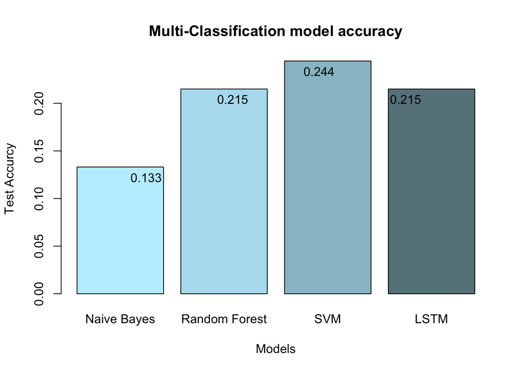

```r
err.all = c(0.1331, 0.215, 0.2444, 0.215)
barplot(err.all, xlab="Models", ylab="Test Accurcy", names=c("Naive Bayes", "Random Forest", "SVM", "LSTM"), col=c("lightblue1","lightblue2", "lightblue3", "lightblue4"), main = "Multi-Classification model accuracy")
text((err.all),labels=round(err.all,digits=3),pos=1)
```

Instead of using 16 labels to do the modeling, since all dimensions like Extroversion and Introversion are independent to each other, we can seperate this problem into 4 individual binary classification problems and do the modeling.

1. Extroversion or Introversion Classification Using Naive Bayes:

```r
classifier_EorI_NB <- naiveBayes(EorI ~ avg_comment_length + comment_length_var + Sentiment + Ellipses + Exclamation + Question + Links + Picture + Emojies + Upper, data = training, usekernel = T)
```

```r
y_pred_EorI_NB <- predict(classifier_EorI_NB, newdata = testing)
cm_EorI_NB <- table(testing$EorI, y_pred_EorI_NB)
cm_EorI_NB
```

```
##    y_pred_EorI_NB
##        0    1
##   0 1222  123
##   1  321   69
```

```r
confusionMatrix(cm_EorI_NB)
```

```
## Confusion Matrix and Statistics
##
##    y_pred_EorI_NB
##        0    1
##   0 1222  123
##   1  321   69
##
##                Accuracy : 0.7441
##                  95% CI : (0.7229, 0.7645)
##     No Information Rate : 0.8893
##     P-Value [Acc > NIR] : 1
##
##                   Kappa : 0.1043
##
##  Mcnemar's Test P-Value : <2e-16
##
##             Sensitivity : 0.7920
##             Specificity : 0.3594
##          Pos Pred Value : 0.9086
##          Neg Pred Value : 0.1769
##              Prevalence : 0.8893
##          Detection Rate : 0.7043
##    Detection Prevalence : 0.7752
##       Balanced Accuracy : 0.5757
##
##        'Positive' Class : 0
##
```

Using SVM:

```r
classifier_EorI_SVM <- svm(EorI ~ avg_comment_length + comment_length_var + Sentiment + Ellipses + Exclamation + Question + Links + Picture + Emojies + Upper, data = training, type = "C-classification", kernel = "linear")
```

```r
y_pred_EorI_SVM = predict(classifier_EorI_SVM, newdata = testing)
cm_EorI_SVM <- table(testing$EorI, y_pred_EorI_SVM)
cm_EorI_SVM
```

```
##    y_pred_EorI_SVM
##        0    1
##   0 1345    0
##   1  390    0
```

```r
confusionMatrix(cm_EorI_SVM)
```

```
## Confusion Matrix and Statistics
##
##    y_pred_EorI_SVM
##        0    1
##   0 1345    0
##   1  390    0
##
##                Accuracy : 0.7752
##                  95% CI : (0.7548, 0.7947)
##     No Information Rate : 1
##     P-Value [Acc > NIR] : 1
##
##                   Kappa : 0
##
##  Mcnemar's Test P-Value : <2e-16
##
##             Sensitivity : 0.7752
##             Specificity :     NA
##          Pos Pred Value :     NA
##          Neg Pred Value :     NA
##              Prevalence : 1.0000
##          Detection Rate : 0.7752
##    Detection Prevalence : 0.7752
##       Balanced Accuracy :     NA
##
##        'Positive' Class : 0
##
```

Using Random Forest:

```r
classifier_EorI_RF <- randomForest(EorI ~ avg_comment_length + comment_length_var + Sentiment + Ellipses + Exclamation + Question + Links + Picture + Emojies + Upper, data = training, importance = T, proximity = T)
```

```r
y_pred_EorI_RF = predict(classifier_EorI_RF, newdata = testing)
cm_EorI_RF <- table(testing$EorI, y_pred_EorI_RF)
cm_EorI_RF
```

```
##    y_pred_EorI_RF
##        0    1
##   0 1314   31
##   1  371   19
```

```r
confusionMatrix(cm_EorI_RF)
```

```
## Confusion Matrix and Statistics
##
##    y_pred_EorI_RF
##        0    1
##   0 1314   31
##   1  371   19
##
##                Accuracy : 0.7683
##                  95% CI : (0.7477, 0.788)
##     No Information Rate : 0.9712
##     P-Value [Acc > NIR] : 1
##
##                   Kappa : 0.0372
##
##  Mcnemar's Test P-Value : <2e-16
##
##             Sensitivity : 0.77982
##             Specificity : 0.38000
##          Pos Pred Value : 0.97695
##          Neg Pred Value : 0.04872
##              Prevalence : 0.97118
##          Detection Rate : 0.75735
##    Detection Prevalence : 0.77522
##       Balanced Accuracy : 0.57991
##
##        'Positive' Class : 0
##
```

Comparison:

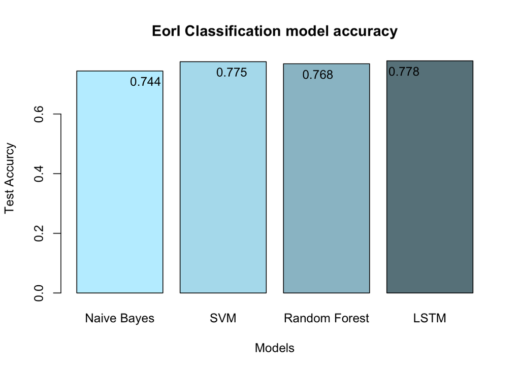

```r
err.all = c(0.7441, 0.7752, 0.7683,0.7781)
barplot(err.all, xlab="Models", ylab="Test Accurcy", names=c("Naive Bayes", "SVM", "Random Forest", "LSTM"),col = c("lightblue1", "lightblue2", "lightblue3", "lightblue4"), main = "EorI Classification model accuracy")
text((err.all),labels=round(err.all,digits=3),pos=1)
```

2. Sensing or Intuition Classification Using Naive Bayes:

```r
classifier_NorS_NB <- naiveBayes(NorS ~ avg_comment_length + comment_length_var + Sentiment + Ellipses + Exclamation + Question + Links + Picture + Emojies + Upper, data = training, usekernel = T)
```

```r
y_pred_NorS_NB <- predict(classifier_NorS_NB, newdata = testing)
cm_NorS_NB <- table(testing$NorS, y_pred_NorS_NB)
cm_NorS_NB
```

```
##    y_pred_NorS_NB
##        0    1
##   0 1442   58
##   1  222   13
```

```r
confusionMatrix(cm_NorS_NB)
```

```
## Confusion Matrix and Statistics
##
##    y_pred_NorS_NB
##        0    1
##   0 1442   58
##   1  222   13
##
##                Accuracy : 0.8386
##                  95% CI : (0.8204, 0.8556)
##     No Information Rate : 0.9591
##     P-Value [Acc > NIR] : 1
##
##                   Kappa : 0.0236
##
##  Mcnemar's Test P-Value : <2e-16
##
##             Sensitivity : 0.86659
##             Specificity : 0.18310
##          Pos Pred Value : 0.96133
##          Neg Pred Value : 0.05532
##              Prevalence : 0.95908
##          Detection Rate : 0.83112
##    Detection Prevalence : 0.86455
##       Balanced Accuracy : 0.52484
##
##        'Positive' Class : 0
##
```

Using SVM:

```r
classifier_NorS_SVM <- svm(NorS ~ avg_comment_length + comment_length_var + Sentiment + Ellipses + Exclamation + Question + Links + Picture + Emojies + Upper, data = training, type = "C-classification", kernel = "linear")
```

```r
y_pred_NorS_SVM = predict(classifier_NorS_SVM, newdata = testing)
cm_NorS_SVM <- table(testing$NorS, y_pred_NorS_SVM)
cm_NorS_SVM
```

```
##    y_pred_NorS_SVM
##        0    1
##   0 1500    0
##   1  235    0
```

```r
confusionMatrix(cm_NorS_SVM)
```

```
## Confusion Matrix and Statistics
##
##    y_pred_NorS_SVM
##        0    1
##   0 1500    0
##   1  235    0
##
##                Accuracy : 0.8646
##                  95% CI : (0.8475, 0.8803)
##     No Information Rate : 1
##     P-Value [Acc > NIR] : 1
##
##                   Kappa : 0
##
##  Mcnemar's Test P-Value : <2e-16
##
##             Sensitivity : 0.8646
##             Specificity :     NA
##          Pos Pred Value :     NA
##          Neg Pred Value :     NA
##              Prevalence : 1.0000
##          Detection Rate : 0.8646
##    Detection Prevalence : 0.8646
##       Balanced Accuracy :     NA
##
##        'Positive' Class : 0
##
```

Using Random Forest:

```r
classifier_NorS_RF <- randomForest(NorS ~ avg_comment_length + comment_length_var + Sentiment + Ellipses + Exclamation + Question + Links + Picture + Emojies + Upper, data = training, importance = T, proximity = T)
```

```r
y_pred_NorS_RF = predict(classifier_NorS_RF, newdata = testing)
cm_NorS_RF <- table(testing$NorS, y_pred_NorS_RF)
cm_NorS_RF
```

```
##    y_pred_NorS_RF
##        0    1
##   0 1499    1
##   1  235    0
```

```r
confusionMatrix(cm_NorS_RF)
```

```
## Confusion Matrix and Statistics
##
##    y_pred_NorS_RF
##        0    1
##   0 1499    1
##   1  235    0
##
##                Accuracy : 0.864
##                  95% CI : (0.8469, 0.8798)
##     No Information Rate : 0.9994
##     P-Value [Acc > NIR] : 1
##
##                   Kappa : -0.0011
##
##  Mcnemar's Test P-Value : <2e-16
##
##             Sensitivity : 0.8645
##             Specificity : 0.0000
##          Pos Pred Value : 0.9993
##          Neg Pred Value : 0.0000
##              Prevalence : 0.9994
##          Detection Rate : 0.8640
##    Detection Prevalence : 0.8646
##       Balanced Accuracy : 0.4322
##
##        'Positive' Class : 0
##
```

Comparison:

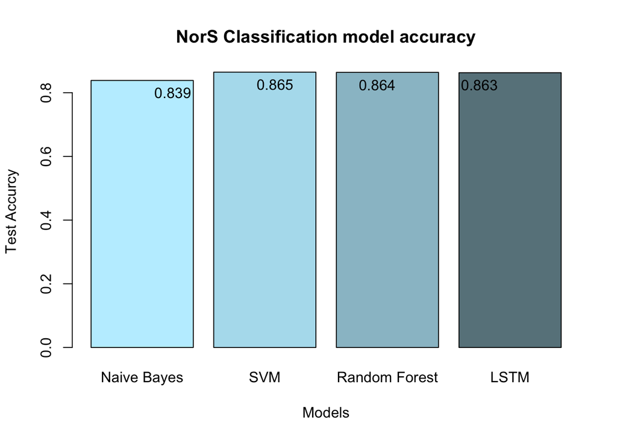

```r
err.all = c(0.8386, 0.8646, 0.864, 0.8629)
barplot(err.all, xlab="Models", ylab="Test Accurcy", names=c("Naive Bayes", "SVM", "Random Forest", "LSTM"),col=c("lightblue1","lightblue2", "lightblue3","lightblue4"), main = "NorS Classification model accuracy")
text((err.all),labels=round(err.all,digits=3),pos=1)
```

3. Thinking or Feeling Classification Using Naive Bayes:

```r
classifier_TorF_NB <- naiveBayes(TorF ~ avg_comment_length + comment_length_var + Sentiment + Ellipses + Exclamation + Question + Links + Picture + Emojies + Upper, data = training, usekernel = T)
```

```r
y_pred_TorF_NB <- predict(classifier_TorF_NB, newdata = testing)
cm_TorF_NB <- table(testing$TorF, y_pred_TorF_NB)
cm_TorF_NB
```

```
##    y_pred_TorF_NB
##       0   1
##   0 569 361
##   1 314 491
```

```r
confusionMatrix(cm_TorF_NB)
```

```
## Confusion Matrix and Statistics
##
##    y_pred_TorF_NB
##       0   1
##   0 569 361
##   1 314 491
##
##                Accuracy : 0.611
##                  95% CI : (0.5876, 0.634)
##     No Information Rate : 0.5089
##     P-Value [Acc > NIR] : < 2e-16
##
##                   Kappa : 0.2209
##
##  Mcnemar's Test P-Value : 0.07664
##
##             Sensitivity : 0.6444
##             Specificity : 0.5763
##          Pos Pred Value : 0.6118
##          Neg Pred Value : 0.6099
##              Prevalence : 0.5089
##          Detection Rate : 0.3280
##    Detection Prevalence : 0.5360
##       Balanced Accuracy : 0.6103
##
##        'Positive' Class : 0
##
```

Using SVM:

```r
classifier_TorF_SVM <- svm(TorF ~ avg_comment_length + comment_length_var + Sentiment + Ellipses + Exclamation + Question + Links + Picture + Emojies + Upper, data = training, type = "C-classification", kernel = "linear")
```

```r
y_pred_TorF_SVM = predict(classifier_TorF_SVM, newdata = testing)
cm_TorF_SVM <- table(testing$TorF, y_pred_TorF_SVM)
cm_TorF_SVM
```

```
##    y_pred_TorF_SVM
##       0   1
##   0 645 285
##   1 335 470
```

```r
confusionMatrix(cm_TorF_SVM)
```

```
## Confusion Matrix and Statistics
##
##    y_pred_TorF_SVM
##       0   1
##   0 645 285
##   1 335 470
##
##                Accuracy : 0.6427
##                  95% CI : (0.6196, 0.6652)
##     No Information Rate : 0.5648
##     P-Value [Acc > NIR] : 2.502e-11
##
##                   Kappa : 0.2786
##
##  Mcnemar's Test P-Value : 0.04908
##
##             Sensitivity : 0.6582
##             Specificity : 0.6225
##          Pos Pred Value : 0.6935
##          Neg Pred Value : 0.5839
##              Prevalence : 0.5648
##          Detection Rate : 0.3718
##    Detection Prevalence : 0.5360
##       Balanced Accuracy : 0.6403
##
##        'Positive' Class : 0
##
```

Using Random Forest:

```r
classifier_TorF_RF <- randomForest(TorF ~ avg_comment_length + comment_length_var + Sentiment + Ellipses + Exclamation + Question + Links + Picture + Emojies + Upper, data = training, importance = T, proximity = T)
```

```r
y_pred_TorF_RF = predict(classifier_TorF_RF, newdata = testing)
cm_TorF_RF <- table(testing$TorF, y_pred_TorF_RF)
cm_TorF_RF
```

```
##    y_pred_TorF_RF
##       0   1
##   0 655 275
##   1 328 477
```

```r
confusionMatrix(cm_TorF_RF)
```

```
## Confusion Matrix and Statistics
##
##    y_pred_TorF_RF
##       0   1
##   0 655 275
##   1 328 477
##
##                Accuracy : 0.6524
##                  95% CI : (0.6295, 0.6749)
##     No Information Rate : 0.5666
##     P-Value [Acc > NIR] : 1.816e-13
##
##                   Kappa : 0.2982
##
##  Mcnemar's Test P-Value : 0.03421
##
##             Sensitivity : 0.6663
##             Specificity : 0.6343
##          Pos Pred Value : 0.7043
##          Neg Pred Value : 0.5925
##              Prevalence : 0.5666
##          Detection Rate : 0.3775
##    Detection Prevalence : 0.5360
##       Balanced Accuracy : 0.6503
##
##        'Positive' Class : 0
##
```

Comparison:

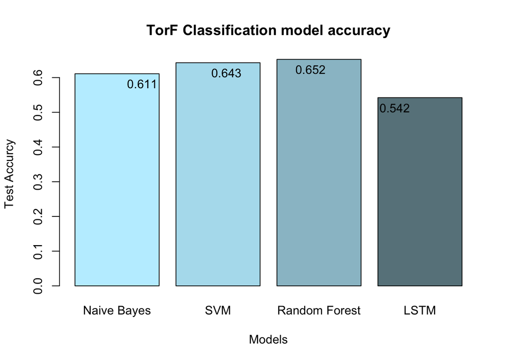

```r
err.all = c(0.611, 0.6427, 0.6524, 0.5421)
barplot(err.all, xlab="Models", ylab="Test Accurcy", names=c("Naive Bayes", "SVM", "Random Forest", "LSTM"),col=c("lightblue1","lightblue2", "lightblue3","lightblue4"), main = "TorF Classification model accuracy")
text((err.all),labels=round(err.all,digits=3),pos=1)
```

4. Judging and Perceiving Classification

Using Naive Bayes:

```r
classifier_JorP_NB <- naiveBayes(JorP ~ avg_comment_length + comment_length_var + Sentiment + Ellipses + Exclamation + Question + Links + Picture + Emojies + Upper, data = training, usekernel = T)
```

```r
y_pred_JorP_NB <- predict(classifier_JorP_NB, newdata = testing)
cm_JorP_NB <- table(testing$JorP, y_pred_JorP_NB)
cm_JorP_NB
```

```
##    y_pred_JorP_NB
##       0   1
##   0 333 347
##   1 493 562
```

```r
confusionMatrix(cm_JorP_NB)
```

```
## Confusion Matrix and Statistics
##
##    y_pred_JorP_NB
##       0   1
##   0 333 347
##   1 493 562
##
##                Accuracy : 0.5159
##                  95% CI : (0.492, 0.5396)
##     No Information Rate : 0.5239
##     P-Value [Acc > NIR] : 0.7572
##
##                   Kappa : 0.0216
##
##  Mcnemar's Test P-Value : 5.645e-07
##
##             Sensitivity : 0.4031
##             Specificity : 0.6183
##          Pos Pred Value : 0.4897
##          Neg Pred Value : 0.5327
##              Prevalence : 0.4761
##          Detection Rate : 0.1919
##    Detection Prevalence : 0.3919
##       Balanced Accuracy : 0.5107
##
##        'Positive' Class : 0
##
```

Using SVM:

```r
classifier_JorP_SVM <- svm(JorP ~ avg_comment_length + comment_length_var + Sentiment + Ellipses + Exclamation + Question + Links + Picture + Emojies + Upper, data = training, type = "C-classification", kernel = "linear")
```

```r
y_pred_JorP_SVM = predict(classifier_JorP_SVM, newdata = testing)
cm_JorP_SVM <- table(testing$JorP, y_pred_JorP_SVM)
cm_JorP_SVM
```

```
##    y_pred_JorP_SVM
##        0    1
##   0    0  680
##   1    0 1055
```

```r
confusionMatrix(cm_JorP_SVM)
```

```
## Confusion Matrix and Statistics
##
##    y_pred_JorP_SVM
##        0    1
##   0    0  680
##   1    0 1055
##
##                Accuracy : 0.6081
##                  95% CI : (0.5846, 0.6311)
##     No Information Rate : 1
##     P-Value [Acc > NIR] : 1
##
##                   Kappa : 0
##
##  Mcnemar's Test P-Value : <2e-16
##
##             Sensitivity :     NA
##             Specificity : 0.6081
##          Pos Pred Value :     NA
##          Neg Pred Value :     NA
##              Prevalence : 0.0000
##          Detection Rate : 0.0000
##    Detection Prevalence : 0.3919
##       Balanced Accuracy :     NA
##
##        'Positive' Class : 0
##
```

Using Random Forest:

```r
classifier_JorP_RF <- randomForest(JorP ~ avg_comment_length + comment_length_var + Sentiment + Ellipses + Exclamation + Question + Links + Picture + Emojies + Upper, data = training, importance = T, proximity = T)
```

```r
y_pred_JorP_RF = predict(classifier_JorP_RF, newdata = testing)
cm_JorP_RF <- table(testing$JorP, y_pred_JorP_RF)
cm_JorP_RF
```

```
##    y_pred_JorP_RF
##       0   1
##   0 102 578
##   1 131 924
```

```r
confusionMatrix(cm_JorP_RF)
```

```
## Confusion Matrix and Statistics
##
##    y_pred_JorP_RF
##       0   1
##   0 102 578
##   1 131 924
##
##                Accuracy : 0.5914
##                  95% CI : (0.5678, 0.6146)
##     No Information Rate : 0.8657
##     P-Value [Acc > NIR] : 1
##
##                   Kappa : 0.0292
##
##  Mcnemar's Test P-Value : <2e-16
##
##             Sensitivity : 0.43777
##             Specificity : 0.61518
##          Pos Pred Value : 0.15000
##          Neg Pred Value : 0.87583
##              Prevalence : 0.13429
##          Detection Rate : 0.05879
##    Detection Prevalence : 0.39193
##       Balanced Accuracy : 0.52647
##
##        'Positive' Class : 0
##
```

Comparison:

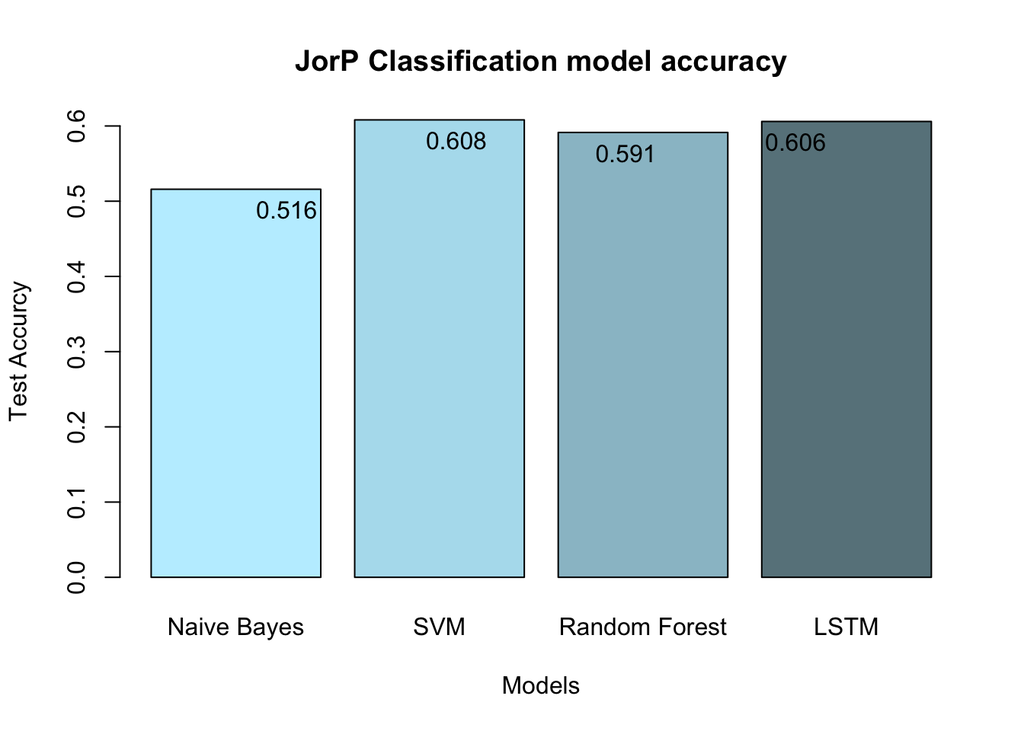

```r
err.all = c(0.5159, 0.6081, 0.5914, 0.606)
barplot(err.all, xlab="Models", ylab="Test Accurcy", names=c("Naive Bayes", "SVM", "Random Forest", "LSTM"),col=c("lightblue1","lightblue2", "lightblue3","lightblue4"), main = "JorP Classification model accuracy")
text((err.all),labels=round(err.all,digits=3),pos=1)
```